# Types of Statistical Analyses

Author

Kálmán Abari

Now that we understand the nature of our data, let’s turn to the types of statistics we can use to interpret them. There are two types of statistics: descriptive and inferential.

# Descriptive Statistics

**Descriptive statistics** are numbers that are used to summarize and describe data. The word “data” refers to the information that has been collected from an experiment, a survey, a historical record, etc. (By the way, *data* is plural. One piece of information is called a *datum*.) If we are analyzing birth certificates, for example, a descriptive statistic might be the percentage of certificates issued in New York State, or the average age of the mother. Any other number we choose to compute also counts as a descriptive statistic for the data from which the statistic is computed. Several descriptive statistics are often used at one time to give a full picture of the data.

Descriptive statistics are just descriptive. They do not involve generalizing beyond the data at hand. Generalizing from our data to another set of cases is the business of inferential statistics, which you’ll be studying in another section. Here we focus on (mere) descriptive statistics.

Some descriptive statistics are shown in Table 1. The table shows the average salaries for various occupations in the United States in 1999. Descriptive statistics like these offer insight into American society. It is interesting to note, for example, that we pay the people who educate our children and who protect our citizens a great deal less than we pay people who take care of our feet or our teeth.

Table 1: Average salaries for various U.S. occupations in 1999

| Occupation | Salary |
| --- | --- |
| Pediatricians | $112,760 |
| Dentists | $106,130 |
| Podiatrists | $100,090 |
| Physicists | $76,140 |
| Architects | $53,410 |
| School, clinical, and counseling psychologists | $49,720 |
| Flight attendants | $47,910 |
| Elementary school teachers | $39,560 |
| Police officers | $38,710 |
| Floral designers | $18,980 |

## Frequency Tables

All of the graphical methods shown in this section are derived from frequency tables. Table 2 shows a frequency table for the results of the iMac study; it shows the frequencies of the various response categories. It also shows the relative frequencies, which are the proportion of responses in each category. For example, the relative frequency for “none” of .17 = 85/500.

Table 2: Frequency table for the iMac data

| Previous Ownership | Frequency | Relative Frequency |
| --- | --- | --- |
| None | 85 | .17 |
| Windows | 60 | .12 |
| Macintosh | 355 | .71 |
| Total | 500 | 1.00 |

### Pie Charts

The pie chart in Figure 1 shows the results of the iMac study. In a pie chart, each category is represented by a slice of the pie. The area of the slice is proportional to the percentage of responses in the category. This is simply the relative frequency multiplied by 100. Although most iMac purchasers were Macintosh owners (71%), Apple was encouraged by the 12% of purchasers who were former Windows users, and by the 17% of purchasers who were buying a computer for the first time.

Pie charts are effective for displaying the relative frequencies of a small number of categories. They are not recommended, however, when you have a large number of categories. Pie charts can also be confusing when they are used to compare the outcomes of two different surveys or experiments. In an influential book on the use of graphs, Edward Tufte asserted, “The only worse design than a pie chart is several of them.”[^1]

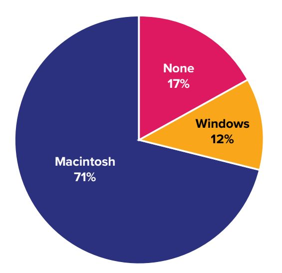

Figure 1: Pie chart of iMac purchases illustrating frequencies of previous computer ownership: 71% of purchasers owned a Macintosh before buying their iMac.

Here is another important point about pie charts. If they are based on a small number of observations, it can be misleading to label the pie slices with percentages. For example, if just 5 people had been interviewed by Apple Computers, and 3 were former Windows users, it would be misleading to display a pie chart with the Windows slice showing 60%. With so few people interviewed, such a large percentage of Windows users might easily have occurred since chance can cause large errors with small samples. In this case, it is better to alert the user of the pie chart to the actual numbers involved. The slices should therefore be labeled with the actual frequencies observed (e.g., 3) instead of with percentages.

### Bar Charts

Bar charts can also be used to represent frequencies of different categories. A bar chart of the iMac purchases is shown in Figure 2. Frequencies are shown on the *y*-axis and the type of computer previously owned is shown on the *x*-axis. Typically, the *y*-axis shows the number of observations in each category rather than the percentage of observations in each category as is typical in pie charts.

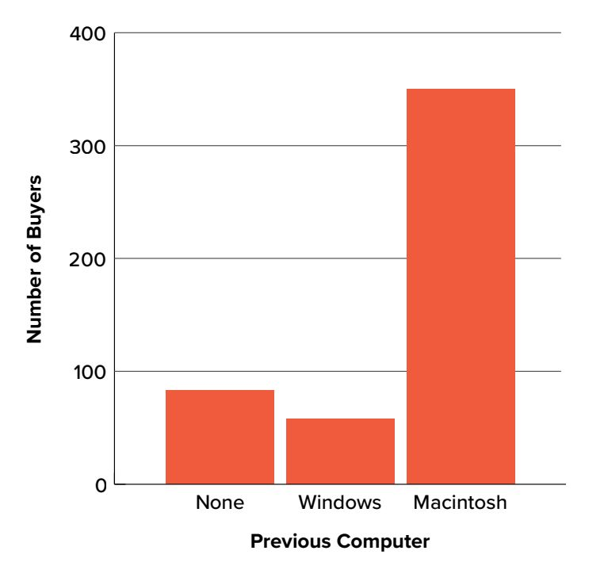

Figure 2: Bar chart of iMac purchases as a function of previous computer ownership.

# Inferential Statistics

Descriptive statistics are wonderful at telling us what our data look like. However, what we often want to understand is how our data behave. What variables are related to other variables? Under what conditions will the value of a variable change? Are two groups different from each other, and if so, are people within each group different or similar? These are the questions answered by inferential statistics, and inferential statistics are how we generalize from our sample back up to our population. Unit 2 and Unit 3 are all about **inferential statistics**, the formal analyses and tests we run to make conclusions about our data.

# A note about statistical software

Many pieces of technology support statistical analysis and quantitative data analysis done by psychologists. Commonly used technologies include the proprietary Statistical Package for the Social Sciences (SPSS), the free and open-source tool *jamovi*, and the programming language R. Several of the figures used in this text were generated using *jamovi*, but providing an overview or introduction to these technologies is outside the scope of this work. Instruction manuals can be found on the [*jamovi* website](https://www.jamovi.org/).

# Mathematical notation

As noted earlier, statistics is not math. It does, however, use math as a tool. Many statistical formulas involve summing numbers. Fortunately, there is a convenient notation for expressing summation. This section covers the basics of this summation notation.

Let’s say we have a variable $X$ that represents the weights (in grams) of 4 grapes:

| Grape | $X$ |
| --- | --- |
| Grape 1 | 4.6 |
| Grape 2 | 5.1 |
| Grape 3 | 4.9 |
| Grape 4 | 4.4 |

We label the weight of Grape 1 as $X_1$, of Grape 2 as $X_2$, etc. The following formula means to sum up the weights of the four grapes:

$$\sum_{i=1}^4X_i$$

The Greek letter $\sum$ indicates summation. The `i = 1` at the bottom indicates that the summation is to start with $X_1$, and the 4 at the top indicates that the summation will end with $X_4$. The “$X_i$” indicates that $X$ is the variable to be summed as $i$ goes from 1 to 4. Therefore,

$$\sum_{i=1}^4X_i=X_1+X_2+X_3+X_4=4.6+5.1+4.9+4.4=19$$

The symbol

$$\sum_{i=1}^3X_i$$

indicates that only the first 3 scores are to be summed. The index variable $i$ goes from 1 to 3.

# Exercises

1. In your own words, describe why we study statistics.
2. For each of the following, determine if the variable is continuous or discrete:
   1. Time taken to read a book chapter
   2. Favorite food
   3. Cognitive ability
   4. Temperature
   5. Letter grade received in a class
3. For each of the following, determine the level of measurement:
   1. T-shirt size
   2. Time taken to run 100-meter race
   3. First, second, and third place in 100-meter race
   4. Birthplace
   5. Temperature in Celsius

## Footnotes

[^1]: Tufte, E. R. (1983). *The visual display of quantitative information* (p. 178). Graphics Press.